# EIND-468-Final-Report

James Santarpio

2023-12-08

Load in required libraries

```r
library(rugarch)
```

```r
library(ggplot2)
library(tidyverse)
```

S&P 500 data from Yahoo Finance will be used for this analysis. The closing date will be used to estimate daily returns.

```r
SP500 <- read.csv("S&P500.csv")
SP500$Date <- as.Date(SP500$Date, format = "%m/%d/%y")
SP500 <- SP500 %>%
  select(Date, Close)
```

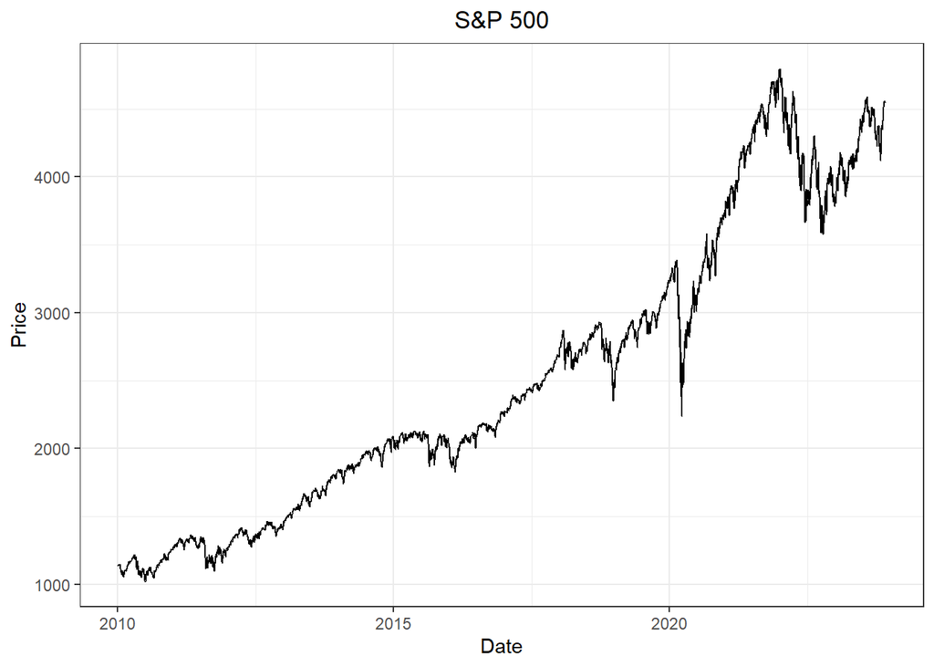

```r
ggplot(SP500, aes(x = Date, y = Close, group = 1))+
  geom_line()+
  labs(x = "Date", y = "Price", title = "S&P 500")+
  theme_bw()+
  theme(plot.title = element_text(hjust = 0.5))
```

There is a clear trend in this index as expected. There appears to be a drop in prices after covid in 2020 as well as additionally increased volatility. Prices recovered quickly after the covid drop, but then decreased again. This increased volatility post 2020 is important to note.

Daily returns calculated as the log of Pt/Pt-1

```r
daily_returns <- SP500 %>%
  mutate(Close = c(NA, diff(log(Close))))
colnames(daily_returns)[2] <- "Daily_Returns"
```

Volatility clustering can be seen in the daily returns data which is a necessary condition for GARCH. Increased volatility post covid is also seen with increased spikes.

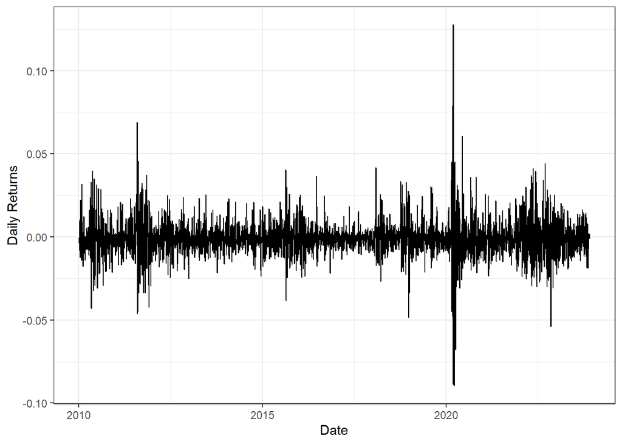

```r
ggplot(daily_returns, aes(x = Date, y = Daily_Returns, group=1))+
  geom_line() +
  labs(y = "Daily Returns")+
  theme_bw()
```

```r
summary(daily_returns)
```

```
##       Date            Daily_Returns
##  Min.   :2010-01-04   Min.   :-0.0896832
##  1st Qu.:2013-06-25   1st Qu.:-0.0056794
##  Median :2016-12-13   Median :-0.0006328
##  Mean   :2016-12-14   Mean   :-0.0003976
##  3rd Qu.:2020-06-08   3rd Qu.: 0.0039050
##  Max.   :2023-11-28   Max.   : 0.1276521
##                       NA's   :1
```

Data is split with training data containing all but the last 29 days.

```r
split_date <- as.Date("2023-10-17")
daily_returns_train <- daily_returns %>%
  filter(Date <= split_date)
daily_returns_test <- daily_returns %>%
  filter(Date > split_date)
```

Estimate a GARCH(1,1) model with the rugarch package and fit to the training data.

```r
garch_spec <- ugarchspec(variance.model = list(model = "sGARCH", garchOrder = c(1, 1)),
                         mean.model = list(armaOrder = c(0, 0)))
garch_fit_1_1 <- ugarchfit(spec = garch_spec, data = na.omit(daily_returns_train))

print(garch_fit_1_1)
```

```
##
## *---------------------------------*
## *          GARCH Model Fit        *
## *---------------------------------*
##
## Conditional Variance Dynamics
## -----------------------------------
## GARCH Model  : sGARCH(1,1)
## Mean Model   : ARFIMA(0,0,0)
## Distribution : norm
##
## Optimal Parameters
## ------------------------------------
##         Estimate  Std. Error  t value Pr(>|t|)
## mu     -0.000759    0.000126  -6.0185 0.000000
## omega   0.000004    0.000002   2.3417 0.019195
## alpha1  0.171489    0.014514  11.8150 0.000000
## beta1   0.800352    0.017658  45.3251 0.000000
##
## Robust Standard Errors:
##         Estimate  Std. Error  t value Pr(>|t|)
## mu     -0.000759    0.000200 -3.78687 0.000153
## omega   0.000004    0.000010  0.36079 0.718258
## alpha1  0.171489    0.025724  6.66657 0.000000
## beta1   0.800352    0.082348  9.71917 0.000000
##
## LogLikelihood : 11495.52
##
## Information Criteria
## ------------------------------------
##
## Akaike       -6.6214
## Bayes        -6.6144
## Shibata      -6.6214
## Hannan-Quinn -6.6189
##
## Weighted Ljung-Box Test on Standardized Residuals
## ------------------------------------
##                         statistic p-value
## Lag[1]                      2.053  0.1519
```

[output cut: 37 more lines]

```
## Negative Sign Bias  1.0131 3.111e-01
## Positive Sign Bias  0.7767 4.374e-01
## Joint Effect       25.7441 1.079e-05 ***
##
##
## Adjusted Pearson Goodness-of-Fit Test:
## ------------------------------------
##   group statistic p-value(g-1)
## 1    20     155.2    2.122e-23
## 2    30     171.6    3.490e-22
## 3    40     192.9    2.924e-22
## 4    50     205.0    5.689e-21
##
##
## Elapsed time : 0.5142391
```

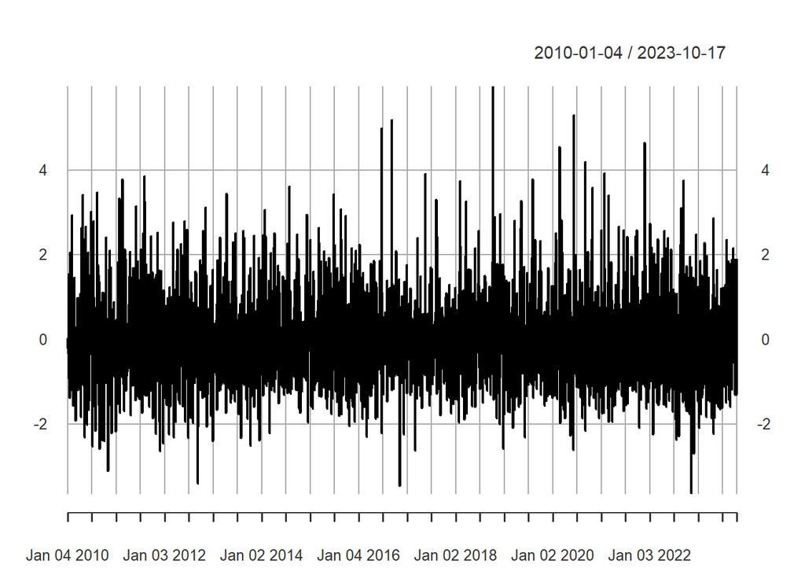

```r
standardized_residuals <- residuals(garch_fit_1_1, standardize = TRUE)

plot(standardized_residuals, main = "", xlab = "", axes = FALSE)
qqline(standardized_residuals)
```

Residuals do not appear normally distributed, an assumption of GARCH. In particular the right side seems to have thick tails.

Calculate forecast and forecast errors

```r
garch_forecast <- ugarchforecast(garch_fit_1_1, newdata = daily_returns_test, n.ahead = nrow(daily_returns_test))
forecasted_volatility <- sigma(garch_forecast)

forecast_errors <- daily_returns_test$Daily_Returns - forecasted_volatility
```

Plot the forecasted daily returns for the last 29 days

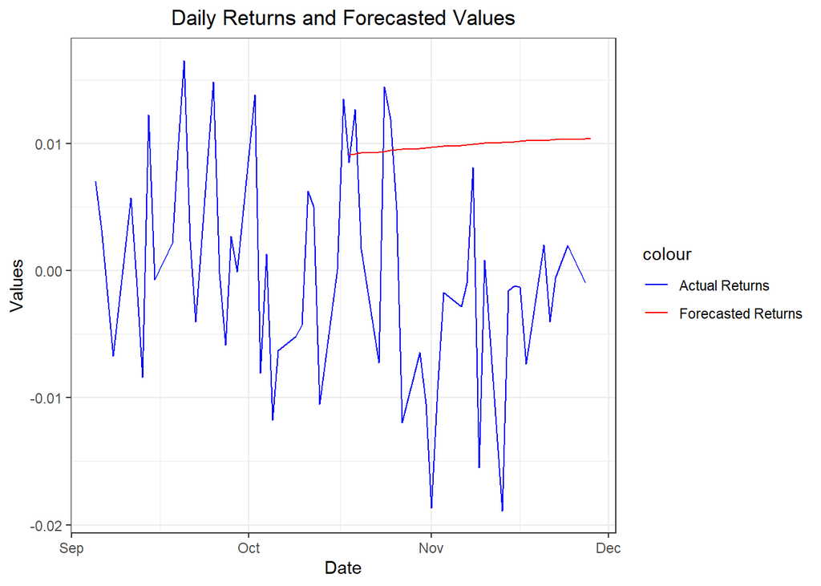

```r
daily_returns$Forecasted_Returns <- NA
daily_returns$Forecasted_Returns[1:29] <- rev(forecasted_volatility)

ggplot(head(daily_returns, n = 60), aes(x = Date))+
  geom_line(aes(y = Daily_Returns, color = "Actual Returns"))+
  geom_line(aes(y = Forecasted_Returns, color = "Forecasted Returns"))+
  labs(title = "Daily Returns and Forecasted Values", y = "Values", x = "Date") +
  scale_color_manual(values = c("Actual Returns" = "blue", "Forecasted Returns" = "red"), guide = "legend") +
  theme_bw() +
  theme(plot.title = element_text(hjust = 0.5))
```